# LMA analysis

Teresa Bohner

5/28/2021

## Questions/Goals

This is my general take on what the overarching goals of this analysis are. Just trying to write down everything. Can be adjusted as necessary.

1. Assess/quantify shifts in LMA
2. Identify/quantify overall climate drivers of fluctuations/shifts in LMA
3. Are some PFTs more responsive than others?
4. Do temporal shifts reflect what we’d expect from spatial differences?

```r
library(tidyverse)
library(GGally)
library(lme4)
library(DHARMa)
library(ggeffects)
```

## Data

For now I filtered out any site/plots that have fewer than 10 observations.

```r
alldata <- read.csv("LMA_and_climate_allData.csv") %>%
  mutate(plot=ifelse(!is.na(plotID), plotID, plot)) %>%
  group_by(site, plot) %>%
  mutate(nobs=n()) %>%
  filter(nobs>=10)
```

There are ~1k obs that have no iLMA (and also have other missing info…they only have environmental data)

[output not shown]

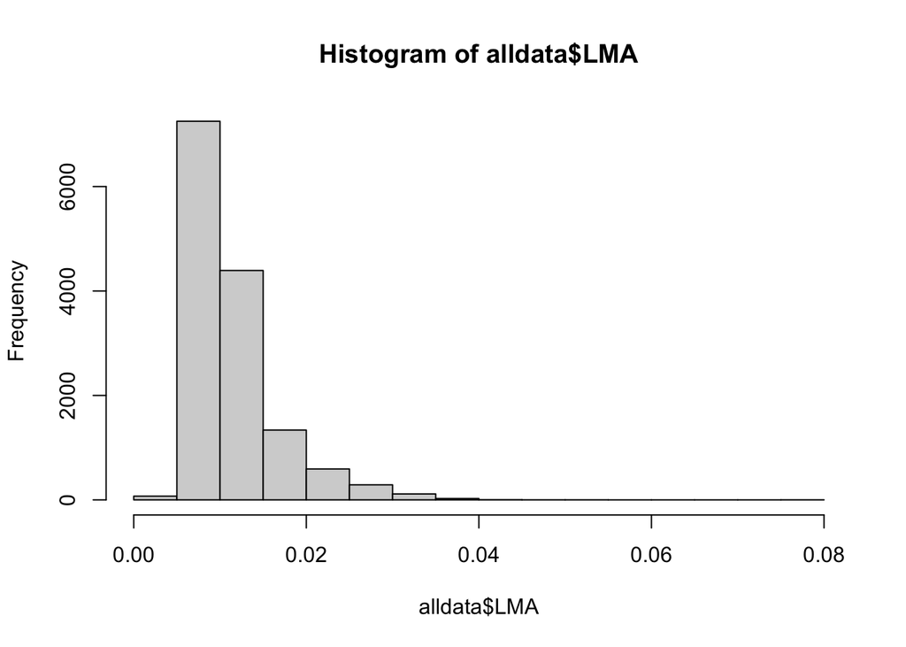

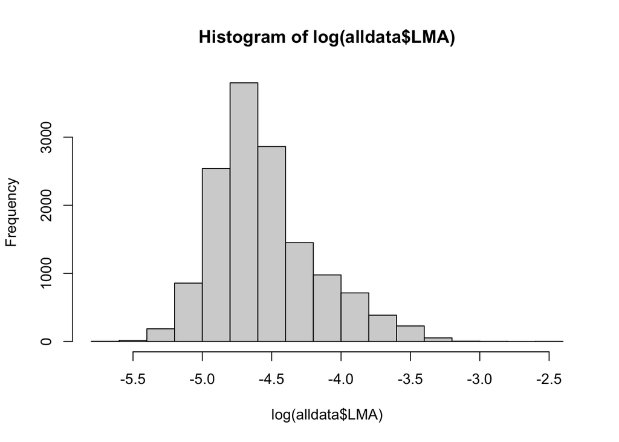

## Changes over time

Changes over time will be tricky. Even with an AR1 term we still get some autocorrelation of the residuals. Looks like we have an overall decline in log(LMA over time). Looks like the plot to plot variability in changes through time is pretty small

```r
sub <- alldata %>%
  mutate(plot=ifelse(is.na(plot), "1", plot)) %>%
  filter_at(vars(year, site, LMA), all_vars(!is.na(.))) %>%
  mutate_at(vars(LMA), log) %>%
  filter(str_detect(site, "ANDT")) %>%
  mutate_at(vars(year), scale)

sub <- alldata %>%
  filter_at(vars(year, site, LMA), all_vars(!is.na(.))) %>%
  mutate_at(vars(LMA), log) %>%
  filter(!is.na(plot)) %>%
  filter(site%in%c( "SOAP", "SERC", "ORNL", "DEJU", "JERC", "TALL", "HARV", "GRSM")) %>%
  mutate_at(vars(year), scale)

ggplot(sub, aes(year, LMA, color=site)) +
  geom_point() +
  geom_smooth(method='lm')

ggplot(sub, aes(year, VPDmax, color=site)) +
  geom_point() +
  geom_smooth(method='lm')

sub_sub <- alldata %>%
  filter_at(vars(year, site, LMA), all_vars(!is.na(.))) %>%
  mutate_at(vars(LMA), log) %>%
  filter(!is.na(plot)) %>%
  filter(site%in%c( "SERC")) %>%
  mutate_at(vars(year), scale)

ggplot(sub_sub, aes(year, LMA, color=plot)) +
  geom_point() +
  geom_smooth( se=F)

# library(brms)
#
# b1 <- brm(LMA~year + (year|site), data=sub, cores=4, iter=1000)
# b2 <- brm(Tmean~year + (year|site), data=sub, cores=4, iter=1000)

library(tidybayes)
get_variables(b1)

draws <- b1 %>%
  spread_draws(b_year, r_site[site,term]) %>%
  mutate(lma_shift=b_year +r_site) %>%
  filter(term=='year') %>%
  dplyr::select(-c(b_year, r_site))

draws2 <- b2 %>%
  spread_draws(b_year, r_site[site,term]) %>%
  mutate(temp_shift=b_year +r_site) %>%
  filter(term=='year') %>%
  dplyr::select(-c(b_year, r_site))

# draws2 <- b2 %>%
#   spread_draws(b_year) %>%
#   rename(temp_shift=b_year)


ggplot(draws, aes(lma_shift, fill=site)) +
  geom_density(alpha=0.6) +
  geom_vline(xintercept = 0, linetype='dashed')

ggplot(draws2, aes(temp_shift, fill=site)) +
  geom_density(alpha=0.6) +
  geom_vline(xintercept = 0, linetype='dashed')


newdata <- left_join(draws, draws2)

newdata2 <- newdata %>%
  group_by(site) %>%
  summarize(lma_mean=mean(lma_shift),
            lma_sd=sd(lma_shift),
            t_mean=mean(temp_shift),
            t_sd=sd(temp_shift))

ggplot(newdata, aes(temp_shift, lma_shift, color=site)) +
  geom_point()

b3 <- brm(lma_shift~temp_shift, data=newdata, cores=4, iter=1000)

b4 <- brm(lma_mean|se(lma_sd)~ 1 + me(t_mean, t_sd), data=newdata2, cores=4, iter=1000)

b5 <- brm(lma_mean|se(lma_sd)~ 1 + t_mean, data=newdata2, cores=4, iter=1000)

m1 <- nlme::lme(LMA~year, data=sub, random= ~year|site/plot)

m2 <- nlme::lme(LMA~year, data=sub, random= ~year|site/plot, correlation = nlme::corAR1(form=~year|site/plot))

plot(nlme::ACF(m2,resType="normalized"),alpha=0.05)

summary(m2)
```

## Changes with environmental variables

If we use environmental variables as predictors we seem to avoid this issue for the most part, although the question is different.

This is a generic first pass at some model competition/selection. Probably want to look at the environmental variables more carefully. As we up the complexity, specifically with any random slopes models we quickly run into convergence issues. Possible reasons to switch to Bayesian.

```r
## create a plot dummy variable for when there is only one plot per site
## filter data so that it doesn't contain any NA's for key variables.
## scale the predictor variables
sub <- alldata %>%
  mutate(plot=ifelse(is.na(plot), "1", plot)) %>%
  filter_at(vars(LMA, year, VPDmean, site), all_vars(!is.na(.))) %>%
  mutate_at(vars(VPDmean, Tmean, precip), scale) %>%
  mutate_at(vars(LMA), log)


m1 <- lmer(LMA~VPDmean +(1|site/plot) + (1|PFT), data=sub, REML = F)
m1a <- lmer(LMA~VPDmax +(1|site/plot) + (1|PFT), data=sub, REML = F)
m2 <- lmer(LMA~Tmean +(1|site/plot) + (1|PFT), data=sub, REML = F)
m2a <- lmer(LMA~Tmax +(1|site/plot) + (1|PFT), data=sub, REML = F)
m2b <- lmer(LMA~Tmin +(1|site/plot) + (1|PFT), data=sub, REML = F)
m3 <- lmer(LMA~precip +(1|site/plot) + (1|PFT), data=sub, REML = F)
m4 <- lmer(LMA~SPEI12 +(1|site/plot) + (1|PFT), data=sub, REML = F)

bbmle::AICtab(m1, m1a, m2, m2a, m2b, m3, m4)
```

```
##     dAIC df
## m2   0.0 6
## m2b 27.9 6
## m3  39.4 6
## m1  41.7 6
## m2a 42.8 6
## m1a 44.5 6
## m4  56.7 6
```

```r
m5 <- lmer(LMA~Tmean + VPDmean +(1|site/plot) + (1|PFT), data=sub, REML = F)
m6 <- lmer(LMA~Tmean + precip +(1|site/plot) + (1|PFT), data=sub, REML = F)
m7 <- lmer(LMA~Tmean + SPEI12 +(1|site/plot) + (1|PFT), data=sub, REML = F)

bbmle::AICtab(m2, m5, m6, m7)
```

```
##    dAIC df
## m6  0.0 7
## m7 42.6 7
## m5 48.2 7
## m2 48.6 6
```

```r
car::vif(m6)
```

```
##    Tmean   precip
## 1.083091 1.083091
```

```r
m8 <- lmer(LMA~Tmean*precip +(1|site/plot) + (1|PFT), data=sub, REML = F)
bbmle::AICtab(m6, m8)
```

```
##    dAIC df
## m8 0.0  8
## m6 9.7  7
```

```r
car::vif(m8)
```

```
##        Tmean       precip Tmean:precip
##     1.090515     1.083128     1.007171
```

```r
performance::icc(m8, by_group = T)
```

```
## # ICC by Group
##
## Group     |   ICC
## -----------------
## plot:site | 0.069
## site      | 0.490
## PFT       | 0.357
```

```r
m6 <- lmer(LMA~Tmean + precip +(1|site/plot) + (1|PFT), data=sub, REML = T)

m8 <- lmer(LMA~Tmean*precip +(1|site/plot) + (1|PFT), data=sub, REML = T)
m9 <- lmer(LMA~Tmean*precip +(1|site/plot) + (Tmean|PFT), data=sub, REML = T)
m10 <- lmer(LMA~Tmean *precip +(1|site/plot) + (precip|PFT), data=sub, REML = T)
m11 <- lmer(LMA~Tmean *precip +(1|site/plot) + (Tmean + precip|PFT), data=sub, REML = T)
```

```
## boundary (singular) fit: see ?isSingular
```

```r
bbmle::AICtab(m8, m9, m10)
```

```
##     dAIC df
## m9   0.0 10
## m10 24.7 10
## m8  79.9 8
```

```r
car::vif(m9)
```

```
##        Tmean       precip Tmean:precip
##     1.002086     1.001863     1.000281
```

```r
performance::r2(m9)
```

```
## # R2 for Mixed Models
##
##   Conditional R2: 0.926
##      Marginal R2: 0.000
```

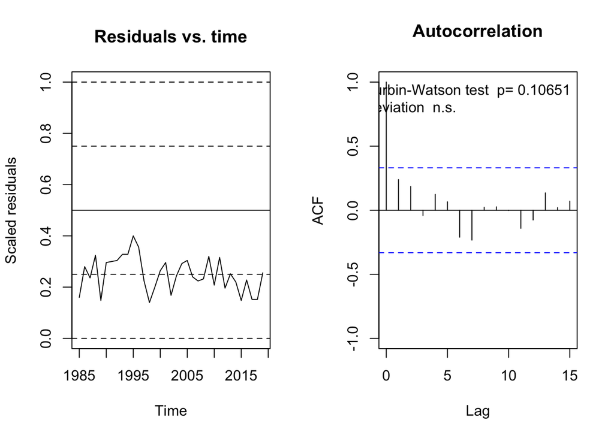

```
##
##  Durbin-Watson test
##
## data:  simulationOutput$scaledResiduals ~ 1
## DW = 1.4687, p-value = 0.1065
## alternative hypothesis: true autocorrelation is not 0
```

```r
## From the DHARMa package
sim_out <- simulateResiduals(fittedModel = m9)
res <- recalculateResiduals(sim_out, group = sub$year) ## this gives us average residuals across all the groups (aggregated by time). Might want to look at them independently.
testTemporalAutocorrelation(res, time = unique(sub$year))
```

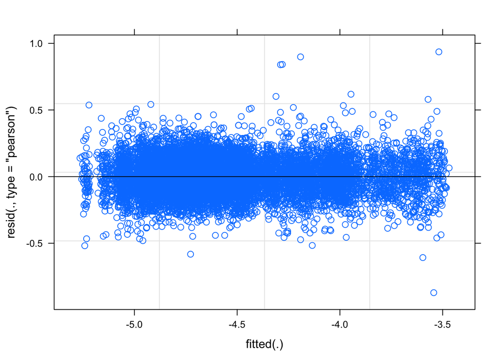

```r
plot(m9)
```

```r
summary(m9)
```

```
## Linear mixed model fit by REML ['lmerMod']
## Formula: LMA ~ Tmean * precip + (1 | site/plot) + (Tmean | PFT)
##    Data: sub
##
## REML criterion at convergence: -16034.3
##
## Scaled residuals:
##     Min      1Q  Median      3Q     Max
## -6.7995 -0.6244 -0.0024  0.6122  7.3078
##
## Random effects:
##  Groups    Name        Variance  Std.Dev. Corr
##  plot:site (Intercept) 0.0134810 0.11611
##  site      (Intercept) 0.0963997 0.31048
##  PFT       (Intercept) 0.0959627 0.30978
##            Tmean       0.0001804 0.01343  -0.81
##  Residual              0.0164115 0.12811
## Number of obs: 14075, groups:  plot:site, 489; site, 98; PFT, 4
##
## Fixed effects:
##               Estimate Std. Error t value
## (Intercept)  -4.403116   0.161375 -27.285
## Tmean        -0.007970   0.006878  -1.159
## precip       -0.007752   0.001147  -6.757
## Tmean:precip -0.003944   0.001098  -3.593
##
## Correlation of Fixed Effects:
##             (Intr) Tmean  precip
## Tmean       -0.764
## precip       0.002  0.043
## Tmean:precp  0.001  0.016  0.006
```

```r
coef(m9)$PFT
```

```
##           (Intercept)         Tmean       precip Tmean:precip
## broadleaf   -4.588091 -0.0104170421 -0.007751548 -0.003944228
## conifer     -3.968990 -0.0253431314 -0.007751548 -0.003944228
## grass       -4.608469  0.0045563139 -0.007751548 -0.003944228
## mixed       -4.446914 -0.0006771094 -0.007751548 -0.003944228
```

```r
# library(brms)

# m8b <- brm(LMA~Tmean + precip +(Tmean|site:plot), data=sub, cores=4, iter=1000)
```

Residuals look ok. Autocorrelation tests look ok. From this model, results say that log(LMA) decreases with increasing temperature and increasing precipitation (Overall within each plot). There is some variability in the intercepts (basically the overall LMA value for each plot) and we allowed for random PFT slopes with temperature (different PFTs can have different responses to changes in temperature). In general conifers have the steepest decline in LMA with temperature, the other PFT’s are much more flat. Be wary of trying to understand the values at this point beyond direct comparsion. The coefficients are based on standardized coefficients so we can say now that the effect of precip here is equivalent to the effect of temperature, but we will need to do some effect sizes/back transformation to say something like for a degree of warming we see X change in LMA.

We could also consider PFT as a fixed effect (although groups are uneven). makes some inference a little easier.

```r
m12 <- lmer(LMA~Tmean + precip + PFT + Tmean:precip + Tmean:PFT +(1|site/plot), data=sub, REML = T)

car::vif(m12)
```

```
##                  GVIF Df GVIF^(1/(2*Df))
## Tmean        2.133868  1        1.460777
## precip       1.090421  1        1.044232
## PFT          1.000003  3        1.000001
## Tmean:precip 1.008993  1        1.004486
## Tmean:PFT    2.074519  3        1.129327
```

```r
performance::r2(m12)
```

```
## # R2 for Mixed Models
##
##   Conditional R2: 0.921
##      Marginal R2: 0.390
```

```r
performance::icc(m12)
```

```
## # Intraclass Correlation Coefficient
##
##      Adjusted ICC: 0.870
##   Conditional ICC: 0.531
```

[figure not shown]

```r
mydf <- ggpredict(m12, terms = c("precip", "PFT"))

ggplot(mydf, aes(x = x, y = predicted, colour = group, label=group)) +
  geom_ribbon(aes(ymin=conf.low, ymax=conf.high, fill = group), alpha=0.3, color=NA)+
  geom_line() +
  xlab ("stnorm(Temp)") + ylab("Predicted iLMA") +
  theme_minimal() +
  ggtitle("Model estimates and 95%CI")
```

```r
means <- modelbased::estimate_means(m12, modulate = "Tmean", length=3)
means
```

```
## Estimated Marginal Means
##
## PFT       | Tmean |  Mean |   SE |         95% CI
## -------------------------------------------------
## broadleaf | -2.92 | -4.57 | 0.05 | [-4.66, -4.48]
## conifer   | -2.92 | -3.88 | 0.06 | [-4.00, -3.77]
## grass     | -2.92 | -4.62 | 0.08 | [-4.78, -4.45]
## mixed     | -2.92 | -4.38 | 0.16 | [-4.70, -4.05]
## broadleaf | -0.05 | -4.60 | 0.05 | [-4.69, -4.51]
## conifer   | -0.05 | -3.96 | 0.06 | [-4.07, -3.84]
## grass     | -0.05 | -4.60 | 0.08 | [-4.77, -4.44]
## mixed     | -0.05 | -4.37 | 0.16 | [-4.69, -4.05]
## broadleaf |  2.83 | -4.63 | 0.05 | [-4.73, -4.54]
## conifer   |  2.83 | -4.03 | 0.06 | [-4.15, -3.91]
## grass     |  2.83 | -4.59 | 0.08 | [-4.75, -4.42]
## mixed     |  2.83 | -4.37 | 0.16 | [-4.69, -4.05]
##
## Marginal means estimated for PFT
```

```r
slopes <- modelbased::estimate_slopes(m12, trend = "Tmean")
```

```
## Note: D.f. calculations have been disabled because the number of observations exceeds 3000.
## To enable adjustments, add the argument 'pbkrtest.limit = 14075' (or larger)
## [or, globally, 'set emm_options(pbkrtest.limit = 14075)' or larger];
## but be warned that this may result in large computation time and memory use.
```

```
## Note: D.f. calculations have been disabled because the number of observations exceeds 3000.
## To enable adjustments, add the argument 'lmerTest.limit = 14075' (or larger)
## [or, globally, 'set emm_options(lmerTest.limit = 14075)' or larger];
## but be warned that this may result in large computation time and memory use.
```

```r
contrasts <- modelbased::estimate_contrasts(m12, modulate = "Tmean", length=3)
contrasts
```

```
## Marginal Contrasts Analysis
##
## Level1    |  Level2 | Tmean | Difference |         95% CI |   SE |  df |         z |      p
## -------------------------------------------------------------------------------------------
## broadleaf | conifer | -0.05 |      -0.65 | [-0.85, -0.45] | 0.08 | Inf |     -8.56 | < .001
## broadleaf | conifer | -2.92 |      -0.69 | [-0.89, -0.49] | 0.08 | Inf |     -9.08 | < .001
## broadleaf | conifer |  2.83 |      -0.60 | [-0.80, -0.40] | 0.08 | Inf |     -7.96 | < .001
## broadleaf |   grass | -0.05 |  -3.64e-04 | [-0.26,  0.25] | 0.10 | Inf | -3.77e-03 | > .999
## broadleaf |   grass | -2.92 |       0.05 | [-0.21,  0.30] | 0.10 | Inf |      0.47 | 0.966
## broadleaf |   grass |  2.83 |      -0.05 | [-0.30,  0.21] | 0.10 | Inf |     -0.47 | 0.965
## broadleaf |   mixed | -0.05 |      -0.23 | [-0.68,  0.22] | 0.17 | Inf |     -1.35 | 0.528
## broadleaf |   mixed | -2.92 |      -0.20 | [-0.65,  0.26] | 0.17 | Inf |     -1.14 | 0.662
## broadleaf |   mixed |  2.83 |      -0.27 | [-0.72,  0.18] | 0.17 | Inf |     -1.56 | 0.404
## conifer   |   grass | -0.05 |       0.65 | [ 0.37,  0.92] | 0.10 | Inf |      6.26 | < .001
## conifer   |   grass | -2.92 |       0.73 | [ 0.46,  1.01] | 0.10 | Inf |      7.09 | < .001
## conifer   |   grass |  2.83 |       0.56 | [ 0.29,  0.83] | 0.10 | Inf |      5.39 | < .001
## conifer   |   mixed | -0.05 |       0.42 | [-0.04,  0.88] | 0.17 | Inf |      2.39 | 0.079
## conifer   |   mixed | -2.92 |       0.49 | [ 0.03,  0.95] | 0.17 | Inf |      2.82 | 0.025
## conifer   |   mixed |  2.83 |       0.34 | [-0.12,  0.80] | 0.17 | Inf |      1.94 | 0.212
## grass     |   mixed | -0.05 |      -0.23 | [-0.72,  0.26] | 0.18 | Inf |     -1.25 | 0.595
## grass     |   mixed | -2.92 |      -0.24 | [-0.73,  0.25] | 0.18 | Inf |     -1.30 | 0.561
## grass     |   mixed |  2.83 |      -0.22 | [-0.71,  0.27] | 0.18 | Inf |     -1.19 | 0.634
##
## Marginal contrasts estimated for PFT
## p-value adjustment method: Holm (1979)
```

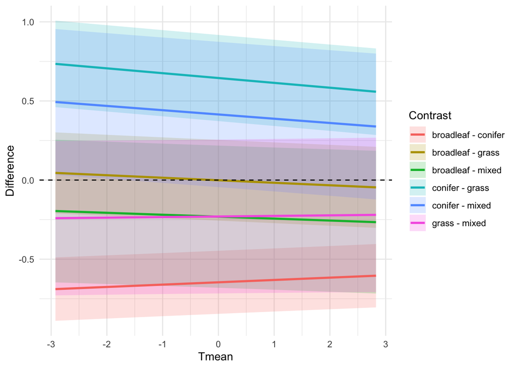

```r
contrasts <- modelbased::estimate_contrasts(m12, modulate = "Tmean", length = 100)
# Create a variable with the two levels concatenated
contrasts$Contrast <- paste(contrasts$Level1, "-", contrasts$Level2)

# Visualise the changes in the differences
ggplot(contrasts, aes(x = Tmean, y = Difference)) +
  geom_ribbon(aes(fill = Contrast, ymin = CI_low, ymax = CI_high), alpha = 0.2) +
  geom_line(aes(colour = Contrast), size = 1) +
  geom_hline(yintercept = 0, linetype = "dashed") +
  theme_minimal() +
  ylab("Difference")
```

## Trait shifits through time

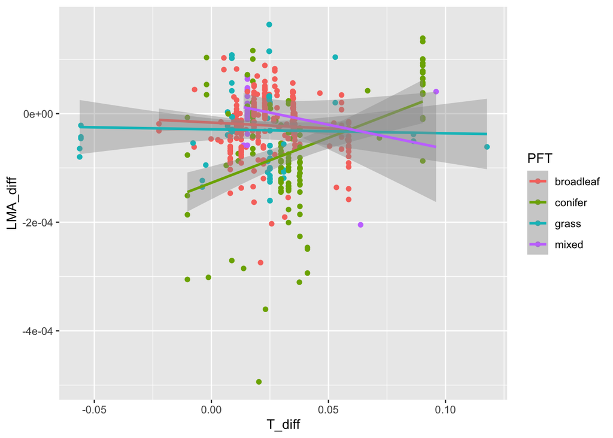

```r
shift_dat <- alldata %>%
  mutate(plot=ifelse(is.na(plot), "1", plot)) %>%
  filter_at(vars(LMA, site), all_vars(!is.na(.))) %>%
  group_by(site, plot) %>%
  mutate(minyear=min(year),
         maxyear=max(year)) %>%
  filter(year==minyear|year==maxyear) %>%
  mutate(t=ifelse(year==minyear, 1, 2))

shift_dat2 <- shift_dat %>%
  ungroup() %>%
  dplyr::select(c(site, PFT, t, year, plot, LMA, Tmean)) %>%
  pivot_wider(id_cols=c(site, plot, PFT), names_from = t, values_from = c(LMA, year, Tmean)) %>%
  mutate(year_diff=year_2-year_1,
         LMA_diff=(LMA_2-LMA_1)/year_diff,
         T_diff=(Tmean_2-Tmean_1)/year_diff) %>%
  filter(year_diff>5)


ggplot(shift_dat2, aes(T_diff, LMA_diff, color=PFT)) +
  geom_point() +
  geom_smooth(method="lm")
```

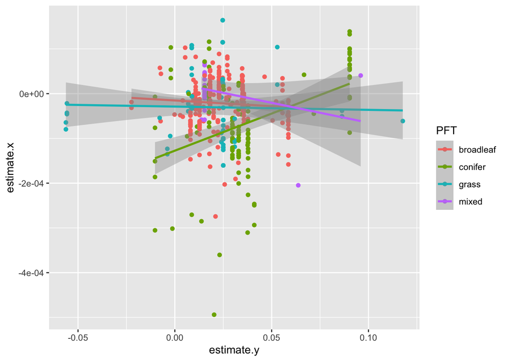

```r
library(broom)
shift_lma <- shift_dat %>%
  group_by(site, plot, PFT) %>%
  do(fit = tidy(lm(LMA ~ year, data = .))) %>%
  unnest() %>%
  filter(term=="year")
shift_tmean <- shift_dat %>%
  group_by(site, plot, PFT) %>%
  do(fit = tidy(lm(Tmean ~ year, data = .))) %>%
  unnest() %>%
  filter(term=="year")
allshift <- left_join(shift_lma, shift_tmean, by=c("site", "plot", "PFT", "term")) %>%
  filter(estimate.y<0.4)

ggplot(allshift, aes(estimate.y, estimate.x, color=PFT)) +
  geom_point() +
  geom_smooth(method="lm")
```